# Updated data: Grosse

2023-06-27

## Statistical Analysis

The data were analyzed using a bayesian logistic regression using the bernoulli family and logit linking function in the R package `brms`. The model priors followed the default in `brms`, using the Student’s T distribution with 3 degrees of freedom. A single model was fit to the data where the outcome variable was the probability of realizing the a stop as an approximant. The outcome was predicted by the population (fixed) effects of group (3 levels: labeled “control”, “experimental”, and “comparison” in the data), and session (3 levels: labeled “1”, “5” and “6”). The random effects included a random slope by participant for session. The model was run using with 2000 iterations of Hamiltonian Monte-Carlo sampling (1000 warm up), across 4 chains and 8 processing cores.

## Results

Figure 1 shows a by group analysis of the raw data for the “control”, “experimental”, and “comparison” groups. The color of the points represent the category of each stop realization, while the y-axis shows the duration of that realization. The x-axis shows the spectral pattern of each stop (continuous (C), Stripe/Burst (S) or whitening (W)).

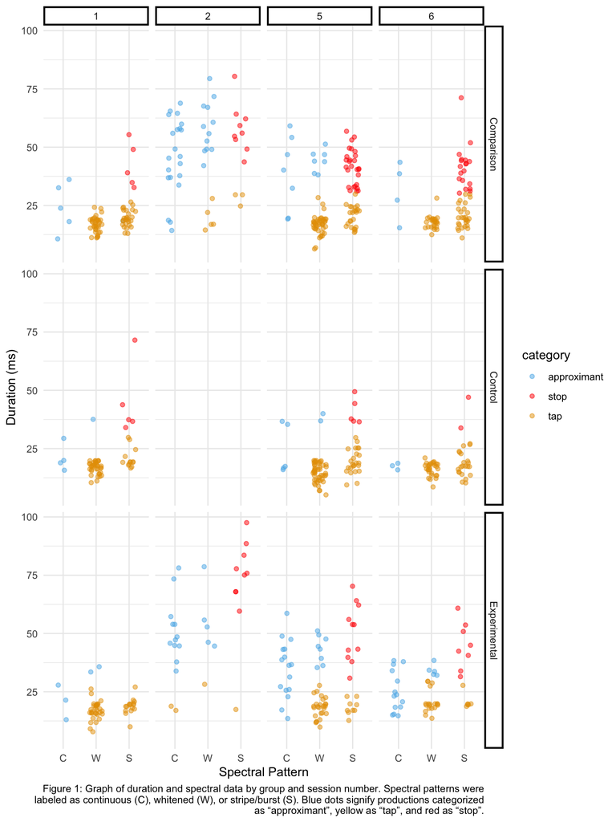

Figure 2 shows just the number of each type of realization per group per session. The figure shows that the number of approximant realizations are relatively low by all groups in session 1, while the quantity of approximant realizations was larger in both sessions 5 and 6 for the experimental groups, but not for the comparison and control groups.

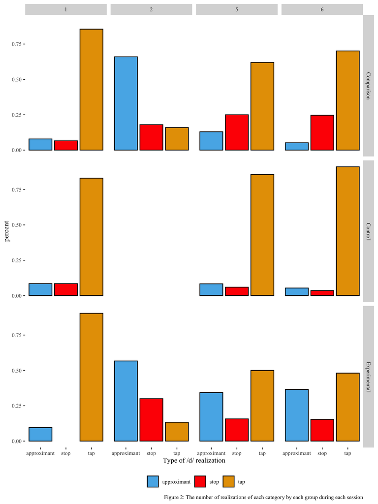

Table 1 shows the output of the Bayesian logistic regression model. Overall, the model’s conditional r squared value suggests that the model explained 0.29 percent of the variance observed in the data. Figure 3 visualizes the model in a forest plot. Each density plot is a summary of the most probable parameter estimates from the Bayesian model, and the values on the right side of the plot are the 95% highest density interval in log-odds.

**Table 1**

|  | Estimate | Est.Error | Q2.5 | Q97.5 |
| --- | --- | --- | --- | --- |
| Intercept | -3.1862335 | 0.7273161 | -4.7338997 | -1.9227387 |
| session5 | 0.4749557 | 0.7757267 | -1.1040515 | 1.9159942 |
| session6 | -0.8903275 | 1.0405349 | -3.1093585 | 0.8481764 |
| groupControl | 0.4015194 | 1.0064710 | -1.5221639 | 2.4397733 |
| groupExperimental | 0.5211473 | 1.0671566 | -1.5638907 | 2.7015543 |
| session5:groupControl | -0.7248827 | 1.0474678 | -2.8547969 | 1.3826488 |
| session6:groupControl | 0.1315875 | 1.2444451 | -2.2928406 | 2.6417258 |
| session5:groupExperimental | 1.2217865 | 1.0407074 | -0.8459317 | 3.2979194 |
| session6:groupExperimental | 2.8706358 | 1.2423445 | 0.7230150 | 5.5411278 |

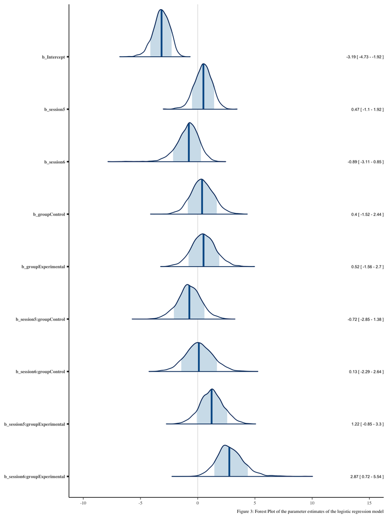

The output of logistic regressions models can be interpreted by adjusting the parameter estimates to a baseline group represented by the intercept of the model. In this case, the intercept of the model tells us the log-odds of an approximant realization by the comparison group at session 1. To figure out how the other groups perform, we simply add appropriate parameter estimates of the model to the intercept as it is appropriate. For example, by adding session 5 (.47) to our intercept (-3.19), we adjust for session while maintaining group (comparison). As a result, our estimate is a log odds of -2.72 of producing a token as an approximant at session 5 for the comparison group.

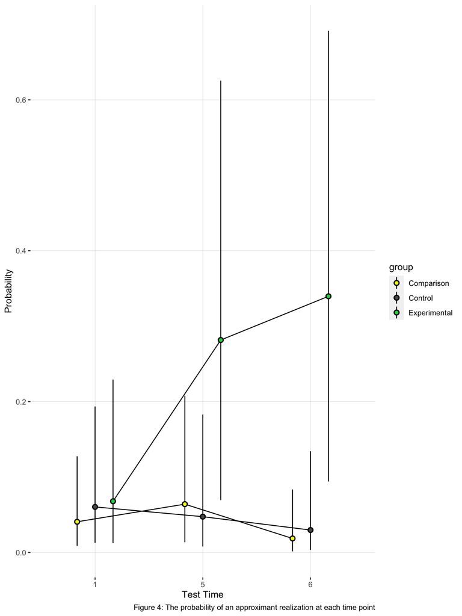

Rather than make arguments using log-odds, it’s also possible to convert this metric to probability. I’ve done so using the `conditional_effects` function from the `brms` package in R. The output of this function carries out the appropriate calculations and converts them to probability. This information is visualized in Figure 4 and the numerical output can be seen in Table 2. As can be seen in both, the experimental group saw an increase in the probability of approximant realization from both session 1 to session 5 and from session 5 to session 6. This increase does not occur in the comparison or control groups.

Table 2: Probability of an approximant realization at each session

| group | Session.1 | Session.5 | Session.6 |
| --- | --- | --- | --- |
| Comparison | 0.041 [0.009-0.128] | 0.064 [0.014-0.208] | 0.019 [0.001-0.084] |
| Control | 0.06 [0.013-0.194] | 0.047 [0.008-0.183] | 0.03 [0.003-0.134] |
| Experimental | 0.068 [0.012-0.229] | 0.282 [0.069-0.626] | 0.34 [0.094-0.692] |

### Individual analysis

In addition to the group analysis, an individual analysis of the probability of approximant realization at each time point was carried out using the random slope by participant for session in the Bayesian Model. First, Figure 5 shows duration, category and spectral information for each participant at each session for the control group. The same information can be seen for the comparison group in Figure 6 and the experimental group in Figure 7.

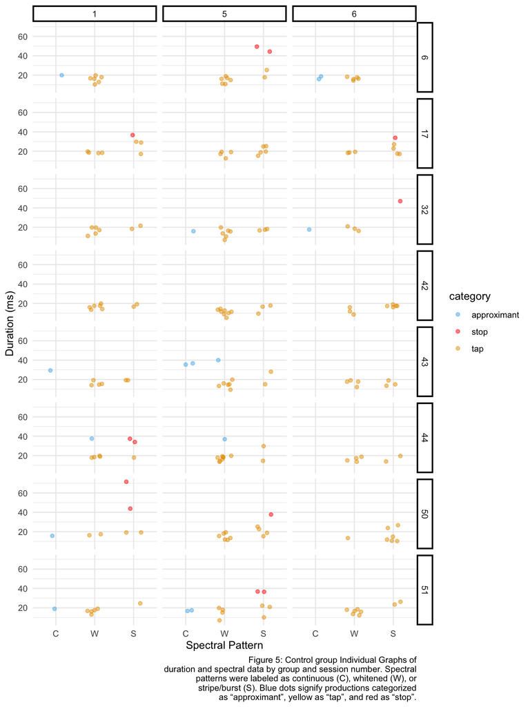

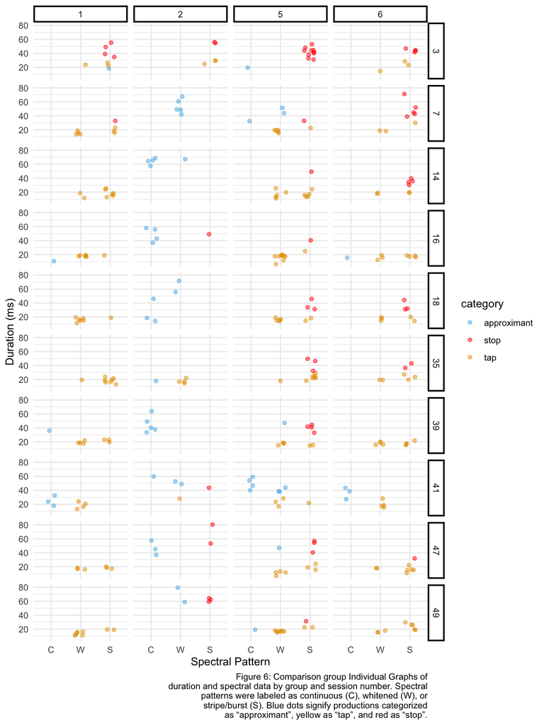

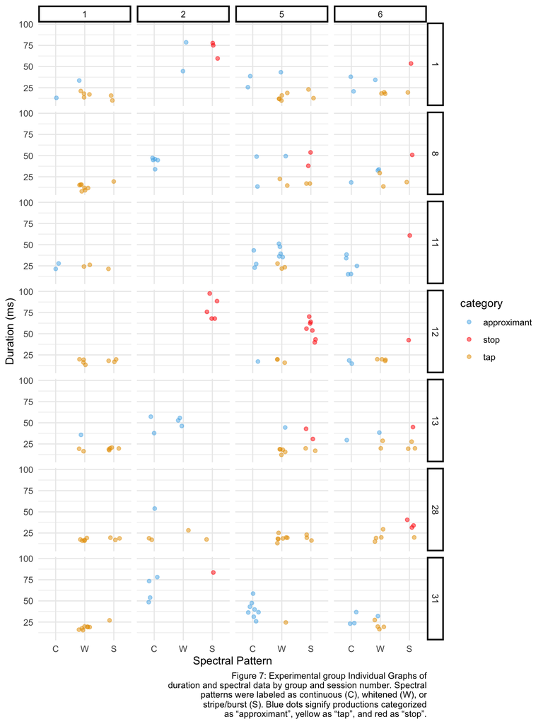

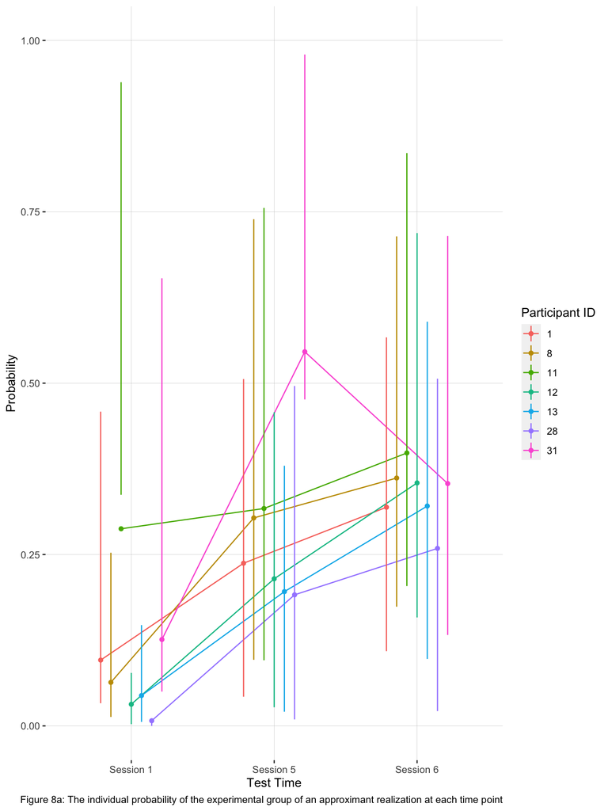

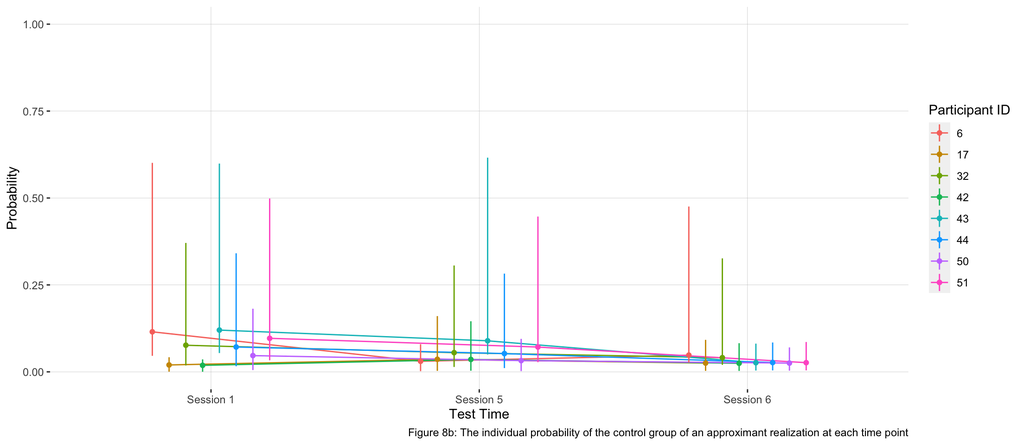

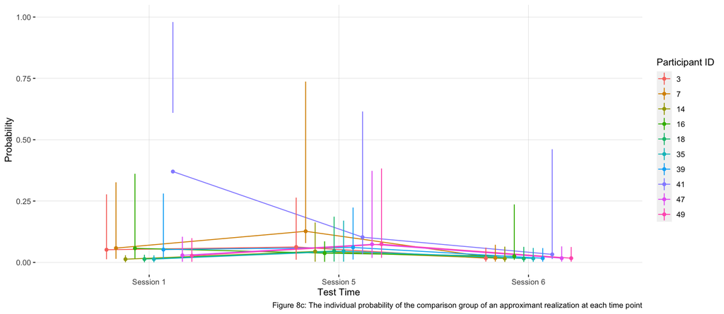

**Table 3: All probabilities of approximant realizations by each participant at each session.**

| participant | session | Probability | Lower | Upper |
| --- | --- | --- | --- | --- |
| 1 | Session 1 | 0.096 | 0.033 | 0.458 |
| 8 | Session 1 | 0.064 | 0.013 | 0.253 |
| 11 | Session 1 | 0.288 | 0.337 | 0.939 |
| 12 | Session 1 | 0.032 | 0.003 | 0.077 |
| 13 | Session 1 | 0.044 | 0.006 | 0.147 |
| 28 | Session 1 | 0.008 | 0.000 | 0.006 |
| 31 | Session 1 | 0.126 | 0.050 | 0.653 |
| 1 | Session 5 | 0.237 | 0.043 | 0.506 |
| 8 | Session 5 | 0.303 | 0.096 | 0.739 |
| 11 | Session 5 | 0.317 | 0.096 | 0.756 |
| 12 | Session 5 | 0.215 | 0.027 | 0.458 |
| 13 | Session 5 | 0.196 | 0.021 | 0.380 |
| 28 | Session 5 | 0.191 | 0.009 | 0.496 |
| 31 | Session 5 | 0.546 | 0.476 | 0.979 |
| 1 | Session 6 | 0.319 | 0.109 | 0.567 |
| 8 | Session 6 | 0.362 | 0.174 | 0.714 |
| 11 | Session 6 | 0.398 | 0.204 | 0.836 |
| 12 | Session 6 | 0.354 | 0.158 | 0.719 |
| 13 | Session 6 | 0.321 | 0.098 | 0.590 |
| 28 | Session 6 | 0.259 | 0.022 | 0.507 |
| 31 | Session 6 | 0.354 | 0.133 | 0.715 |

### Appendix/extras

Here I’ve included the plots of the three groups removed from the main analysis, Comparison-High”, “Control-High-Partial”, and “Experimental-High”. From these visualizations, it can be seen that the groups are overall producing approximants at a high rate in the beginning (session 1), which seems like good rationale for their removal.

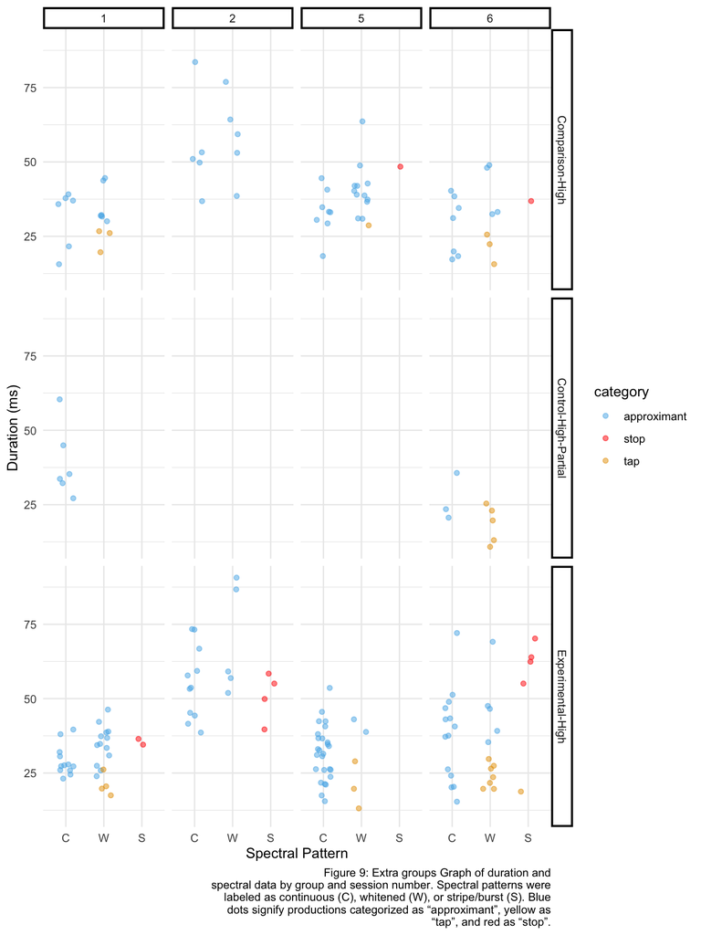

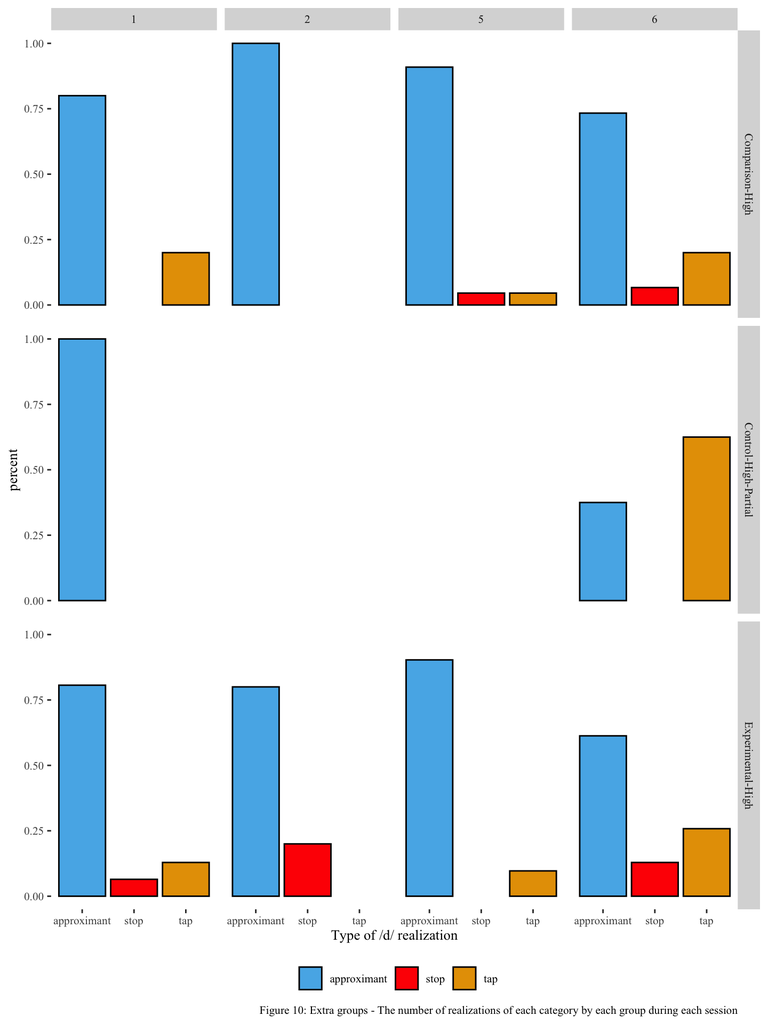

[figure not shown]

[figure not shown]

**Table 4: Amount and percentage of each realization type during all sessions**

| category | group | session | n | mean_ri | sd_ri | mean_wmrv | sd_wmrv | mean_duration | sd_duration | total | percent |
| --- | --- | --- | --- | --- | --- | --- | --- | --- | --- | --- | --- |
| approximant | Comparison | 1 | 6 | 8.19 | 8.04 | 6.02 | 6.73 | 23.29 | 9.61 | 76 | 0.08 |
| stop | Comparison | 1 | 5 | 26.19 | 6.94 | 10.99 | 1.60 | 42.19 | 9.68 | 76 | 0.07 |
| tap | Comparison | 1 | 65 | 10.51 | 6.44 | 6.79 | 3.89 | 17.99 | 3.59 | 76 | 0.86 |
| approximant | Comparison-High | 1 | 12 | 12.71 | 6.00 | 6.51 | 2.19 | 33.43 | 8.40 | 15 | 0.80 |
| tap | Comparison-High | 1 | 3 | 8.56 | 4.31 | 4.77 | 1.64 | 24.16 | 3.91 | 15 | 0.20 |
| approximant | Control | 1 | 5 | 5.57 | 3.89 | 4.10 | 3.58 | 24.30 | 9.00 | 59 | 0.08 |
| stop | Control | 1 | 5 | 18.74 | 7.03 | 18.03 | 12.18 | 44.69 | 15.43 | 59 | 0.08 |
| tap | Control | 1 | 49 | 12.56 | 6.39 | 9.34 | 4.97 | 17.84 | 3.56 | 59 | 0.83 |
| approximant | Control-High-Partial | 1 | 6 | 4.77 | 3.51 | 2.48 | 1.53 | 38.95 | 12.01 | 6 | 1.00 |
| approximant | Experimental | 1 | 5 | 11.90 | 8.09 | 6.93 | 5.76 | 26.31 | 9.27 | 52 | 0.10 |
| tap | Experimental | 1 | 47 | 11.78 | 6.41 | 8.16 | 3.97 | 17.51 | 3.77 | 52 | 0.90 |
| approximant | Experimental-High | 1 | 25 | 10.27 | 7.02 | 5.83 | 3.91 | 32.04 | 6.39 | 31 | 0.81 |
| stop | Experimental-High | 1 | 2 | 12.20 | 5.81 | 7.93 | 4.98 | 35.50 | 1.37 | 31 | 0.06 |
| tap | Experimental-High | 1 | 4 | 14.67 | 3.11 | 7.42 | 2.04 | 20.99 | 3.68 | 31 | 0.13 |
| approximant | Comparison | 2 | 33 | 18.39 | 7.52 | 11.77 | 5.49 | 50.73 | 15.58 | 50 | 0.66 |
| stop | Comparison | 2 | 9 | 25.08 | 7.79 | 17.06 | 5.89 | 58.10 | 10.48 | 50 | 0.18 |
| tap | Comparison | 2 | 8 | 13.41 | 5.95 | 9.69 | 3.72 | 22.77 | 6.13 | 50 | 0.16 |
| approximant | Comparison-High | 2 | 10 | 13.30 | 4.32 | 8.01 | 3.43 | 56.66 | 15.00 | 10 | 1.00 |
| approximant | Experimental | 2 | 17 | 15.58 | 10.93 | 8.91 | 6.85 | 52.79 | 12.95 | 30 | 0.57 |
| stop | Experimental | 2 | 9 | 31.12 | 5.97 | 23.20 | 5.61 | 77.09 | 11.58 | 30 | 0.30 |
| tap | Experimental | 2 | 4 | 15.40 | 5.26 | 12.77 | 0.93 | 20.35 | 5.29 | 30 | 0.13 |
| approximant | Experimental-High | 2 | 16 | 19.02 | 6.74 | 8.78 | 4.91 | 59.54 | 15.23 | 20 | 0.80 |
| stop | Experimental-High | 2 | 4 | 21.76 | 7.44 | 20.53 | 9.49 | 50.76 | 8.19 | 20 | 0.20 |
| approximant | Comparison | 5 | 14 | 13.39 | 10.69 | 7.63 | 6.42 | 41.52 | 11.60 | 108 | 0.13 |
| stop | Comparison | 5 | 27 | 21.48 | 7.13 | 19.22 | 8.09 | 41.58 | 7.52 | 108 | 0.25 |
| tap | Comparison | 5 | 67 | 13.71 | 6.24 | 10.29 | 4.93 | 18.03 | 4.49 | 108 | 0.62 |
| approximant | Comparison-High | 5 | 20 | 11.15 | 5.47 | 7.65 | 5.55 | 37.88 | 9.06 | 22 | 0.91 |
| stop | Comparison-High | 5 | 1 | 9.63 | NA | 4.61 | NA | 48.41 | NA | 22 | 0.05 |
| tap | Comparison-High | 5 | 1 | 0.15 | NA | 1.71 | NA | 28.68 | NA | 22 | 0.05 |
| approximant | Control | 5 | 7 | 8.16 | 6.15 | 4.20 | 2.20 | 28.43 | 11.09 | 84 | 0.08 |
| stop | Control | 5 | 5 | 20.46 | 5.20 | 11.75 | 2.83 | 40.96 | 5.72 | 84 | 0.06 |
| tap | Control | 5 | 72 | 8.99 | 5.44 | 5.21 | 2.74 | 16.25 | 4.84 | 84 | 0.86 |
| approximant | Experimental | 5 | 24 | 11.81 | 9.09 | 8.07 | 7.15 | 37.65 | 11.21 | 70 | 0.34 |
| stop | Experimental | 5 | 11 | 26.15 | 5.86 | 20.77 | 6.18 | 50.44 | 12.39 | 70 | 0.16 |
| tap | Experimental | 5 | 35 | 12.76 | 7.53 | 9.56 | 4.94 | 18.25 | 4.12 | 70 | 0.50 |
| approximant | Experimental-High | 5 | 28 | 9.40 | 6.91 | 5.72 | 4.54 | 32.37 | 9.11 | 31 | 0.90 |
| tap | Experimental-High | 5 | 3 | 13.72 | 2.48 | 9.45 | 1.62 | 20.59 | 7.95 | 31 | 0.10 |
| approximant | Comparison | 6 | 4 | 7.76 | 2.84 | 3.22 | 0.50 | 31.21 | 12.53 | 77 | 0.05 |
| stop | Comparison | 6 | 19 | 20.02 | 7.86 | 10.96 | 5.54 | 41.34 | 9.39 | 77 | 0.25 |
| tap | Comparison | 6 | 54 | 12.12 | 5.24 | 6.48 | 2.16 | 19.07 | 4.23 | 77 | 0.70 |
| approximant | Comparison-High | 6 | 11 | 12.93 | 4.62 | 4.57 | 1.45 | 32.96 | 10.97 | 15 | 0.73 |
| stop | Comparison-High | 6 | 1 | 20.96 | NA | 12.02 | NA | 36.87 | NA | 15 | 0.07 |
| tap | Comparison-High | 6 | 3 | 15.15 | 4.36 | 9.03 | 2.72 | 21.20 | 5.07 | 15 | 0.20 |
| approximant | Control | 6 | 3 | 7.41 | 6.21 | 4.18 | 2.61 | 17.42 | 1.43 | 56 | 0.05 |
| stop | Control | 6 | 2 | 25.01 | 6.58 | 12.78 | 7.21 | 40.45 | 9.32 | 56 | 0.04 |
| tap | Control | 6 | 51 | 11.22 | 5.53 | 5.76 | 2.55 | 17.09 | 3.99 | 56 | 0.91 |
| approximant | Control-High-Partial | 6 | 3 | 8.51 | 4.55 | 3.67 | 2.18 | 26.60 | 7.98 | 8 | 0.38 |
| tap | Control-High-Partial | 6 | 5 | 16.03 | 7.09 | 9.24 | 3.01 | 18.40 | 6.27 | 8 | 0.62 |
| approximant | Experimental | 6 | 19 | 7.66 | 5.26 | 3.20 | 2.40 | 27.48 | 8.59 | 52 | 0.37 |
| stop | Experimental | 6 | 8 | 20.12 | 5.24 | 11.03 | 2.43 | 44.84 | 9.94 | 52 | 0.15 |
| tap | Experimental | 6 | 25 | 9.88 | 4.71 | 5.27 | 2.49 | 20.63 | 4.36 | 52 | 0.48 |
| approximant | Experimental-High | 6 | 19 | 9.40 | 9.00 | 4.64 | 4.21 | 40.27 | 15.11 | 31 | 0.61 |
| stop | Experimental-High | 6 | 4 | 25.32 | 7.16 | 13.07 | 2.45 | 62.91 | 6.21 | 31 | 0.13 |
| tap | Experimental-High | 6 | 8 | 15.70 | 8.55 | 9.40 | 4.75 | 23.38 | 4.10 | 31 | 0.26 |